# Philosophy Data Story

Ananya Iyer

02/02/2022

#WHAT IS PHILOSPHY?

The term “philosophy” means, “love of wisdom.”

Philosophy, in its broadest definition, is an activity in which individuals strive to understand fundamental truths about themselves, the world in which they live, and their relationships to the world and to one another. The philosophy of each academic area is very similar. Philosophy students are always asking, replying, and arguing for their answers to life’s most fundamental issues.

Plato (c. 428–c. 348 BCE) and Aristotle (384–322 BCE) are two of Western philosophy’s most well-known and studied figures. Plato was a student of Socrates, and Aristotle was Plato’s student. As a result, we can see some parallels in their philosophy.

The aim of this story is to potray a contrast in their philosophies by doing some text mining analysis.

```r
library(tidyverse)
```

```r
library(tidytext)
library(ggplot2)
library(dplyr)
library(tidyr)
library(wordcloud)
library(tm)
library(topicmodels)
library(RColorBrewer)
```

```r
d=read.csv("philosophy_data.csv")
```

```r
plato = subset(d, school == "plato")
aristotle=subset(d, school=="aristotle")
```

Plato is considered a pivotal figure in Ancient Greek and Western Philosophy. His teacher was the renowned Socrates. Plato is also considered to be one of the founders of Western Religion and spirituality.

Aristotle was a Greek philosopher and polymath during the Classial period in Ancient Greece. He was a pupil of Plato.

We start of by visually depicting the frequency of words used by both philosophers in their texts.

```r
tidy_plato <- plato %>%
  unnest_tokens(word, sentence_str) %>%
  anti_join(stop_words) %>%
  count(word) %>%
  filter(n > 300)
```

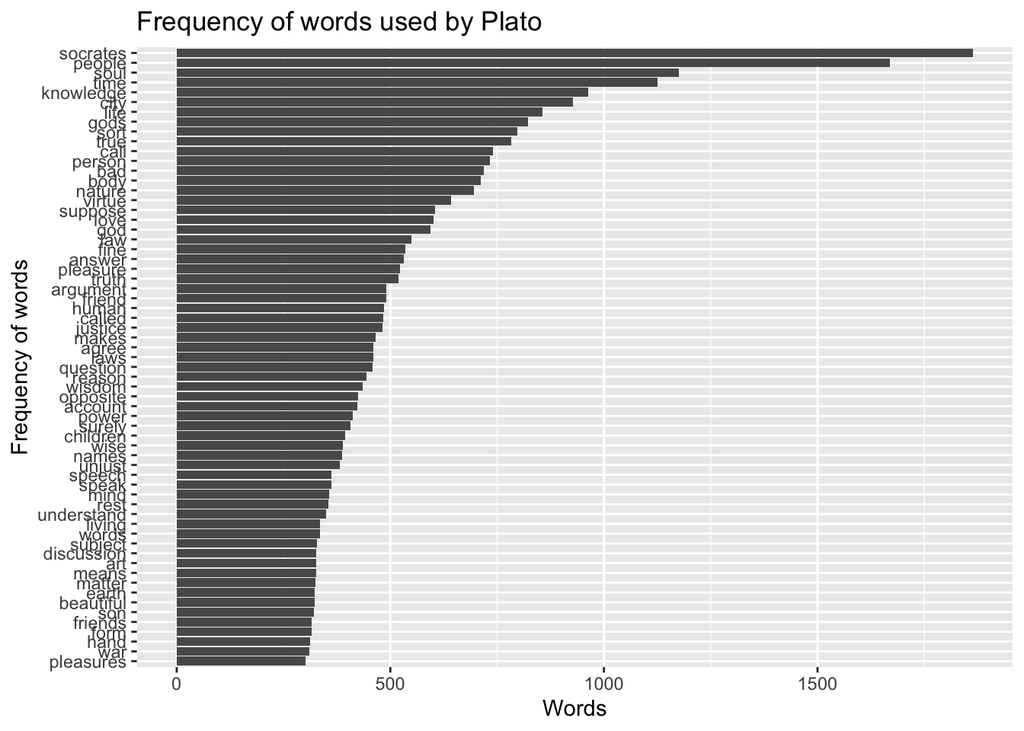

```r
ggplot(tidy_plato, aes(x = reorder(word,n), y = n)) + xlab("Frequency of words") + ylab("Words") + ggtitle("Frequency of words used by Plato") +
  geom_col() +
  coord_flip()
```

```r
tidy_aristotle <- aristotle %>%
  unnest_tokens(word, sentence_str) %>%
  anti_join(stop_words) %>%
  count(word) %>%
  filter(n > 600)
```

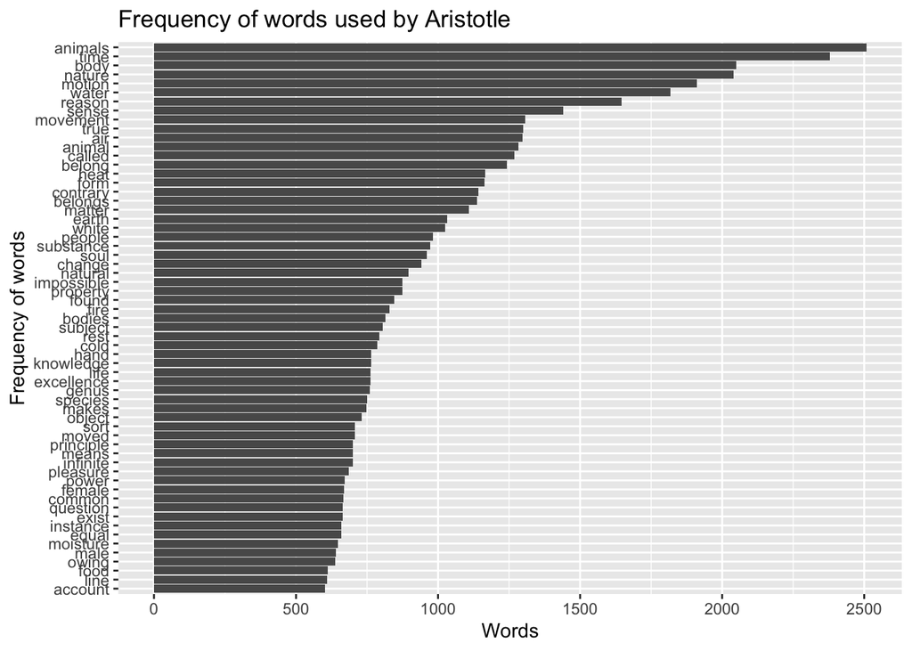

```r
ggplot(tidy_aristotle, aes(x = reorder(word,n), y = n)) + xlab("Frequency of words") + ylab("Words") + ggtitle("Frequency of words used by Aristotle") +
  geom_col() +
  # Flip the plot coordinates
  coord_flip()
```

Although there are similarities in the frequency of words being used, we can see a few comparisons in what might have been their thought process while writing the texts.

In the instance of Plato, his most frequently used word is Socrates. This can signify his devotion and love for his teacher. It is said that Plato never speaks in his own dialogues and speaks as Socrates in most of his texts. His usage of other words such as soul, people, time, knowledge, god shows how Plato’s philosophy is more abstract and mystical.

In the instance of Aristotle, his most frequently used word is animals. His other most frequently used words are nature, body, sense, movement, water. This can suggest that apart from philosophy, Aristotle also investifates areas of science. Aristotle’s philosophy is more practical in nature.

Although Aristotle revered his teacher Plato, this shows the tangent with which Aristotle deiviated from Plato’s teachings.

The frequency of words can also be visualised by the word clouds below-

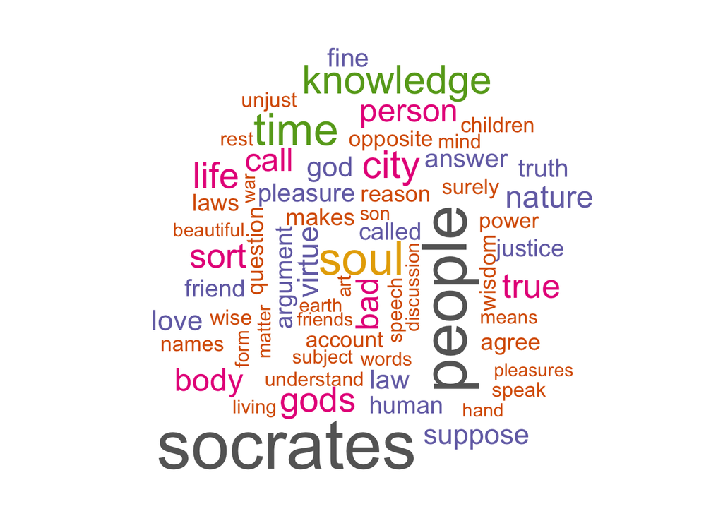

```r
wordcloud(words =tidy_plato$word, freq=tidy_plato$n, max.words =100,
          colors=brewer.pal(8, "Dark2"))
```

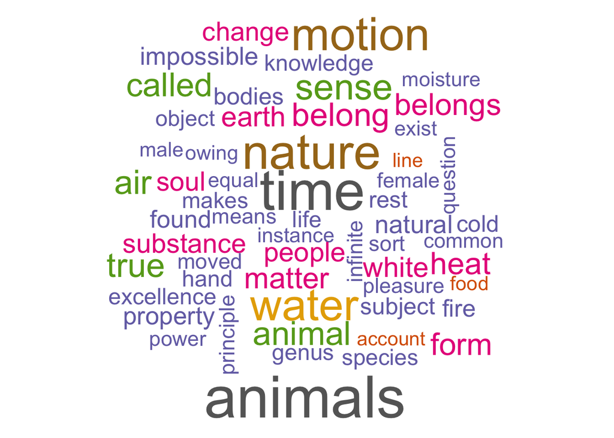

```r
wordcloud(words =tidy_aristotle$word, freq=tidy_aristotle$n, max.words =100,
          colors=brewer.pal(8, "Dark2"))
```

#SENTIMENT ANALYSIS

Using sentiment analysis, we can see that both Plato and Aristotle texts were quite negative in nature followed by positive, fear, trust and anger. This depicts the similarities in their teachings.

```r
tidy_plato <- plato %>%
  unnest_tokens(word, sentence_str) %>%
  anti_join(stop_words) %>%
  count(word)
sentiment_plato= tidy_plato %>%
  inner_join(get_sentiments("nrc")) %>%
  filter(sentiment %in% c("negative", "positive", "fear","trust","anger"))
sentiment_plato %>%
  count(sentiment) %>%
  # Arrange the sentiment counts in descending order
  arrange(desc(n))
```

```
##   sentiment    n
## 1  negative 1711
## 2  positive 1467
## 3      fear  794
## 4     trust  787
## 5     anger  711
```

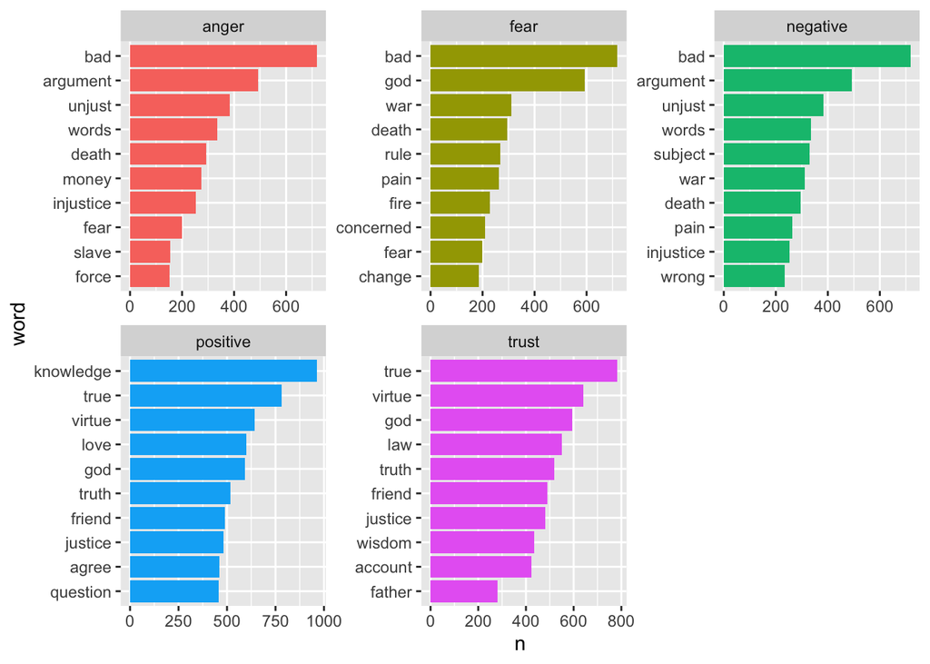

```r
sentiment_plato %>%
  group_by(sentiment) %>%
  # Take the top 10 words for each sentiment
  top_n(10, n) %>%
  ungroup() %>%
  mutate(word = reorder(word, n)) %>%
  # Set up the plot with aes()
  ggplot(aes(word,n, fill=sentiment)) +
  geom_col(show.legend = FALSE) +
  facet_wrap(~ sentiment, scales = "free") +
  coord_flip()
```

```r
tidy_aristotle <- aristotle %>%
  unnest_tokens(word, sentence_str) %>%
  anti_join(stop_words) %>%
  count(word)
sentiment_aristotle= tidy_aristotle %>%
  inner_join(get_sentiments("nrc")) %>%
  filter(sentiment %in% c("negative", "positive", "fear","trust","anger"))
# Count the sentiments in sentiment_aristotle
sentiment_aristotle %>%
  count(sentiment) %>%
  # Arrange the sentiment counts in descending order
  arrange(desc(n))
```

```
##   sentiment    n
## 1  negative 1717
## 2  positive 1348
## 3      fear  770
## 4     trust  725
## 5     anger  677
```

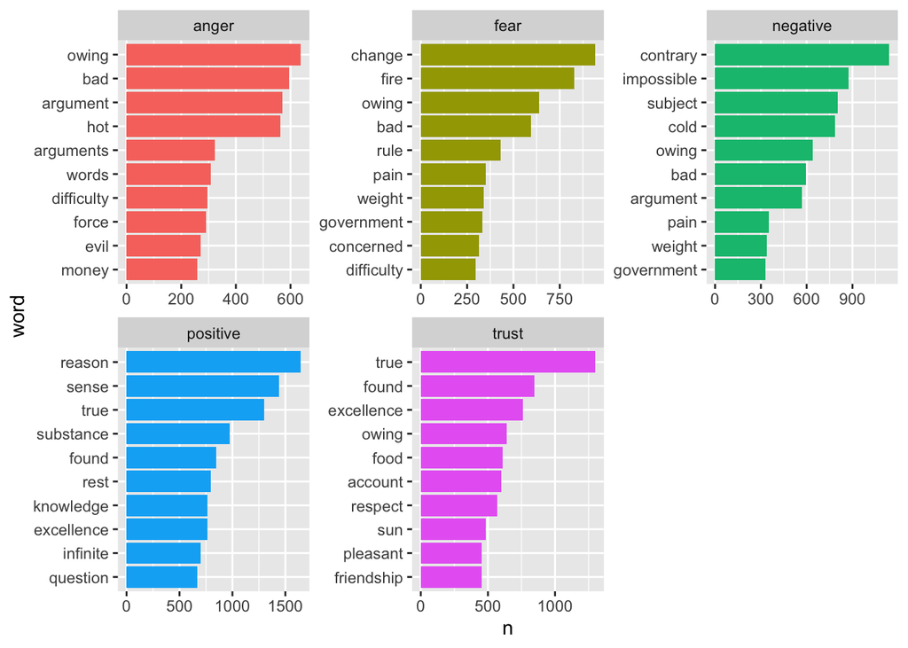

```r
sentiment_aristotle %>%
  group_by(sentiment) %>%
  # Take the top 10 words for each sentiment
  top_n(10, n) %>%
  ungroup() %>%
  mutate(word = reorder(word, n)) %>%
  # Set up the plot with aes()
  ggplot(aes(word,n, fill=sentiment)) +
  geom_col(show.legend = FALSE) +
  facet_wrap(~ sentiment, scales = "free") +
  coord_flip()
```

#TOPIC MODELLING

Using topic modelling, we want to analyse the most common topics that Plato and Aristotle wrote in their teachings.

For Plato, we can cateogorize his topics as - Topic 1- Spirituality Topic 2- Human Nature Topic 3- People

For Aristotle, we can categorize his topics as- Topic 1- Environment Topic 2- Science Topic 3- Virtues

```r
tidy_plato <- plato %>%
  unnest_tokens(word, sentence_str) %>%
  anti_join(stop_words)
dtm_plato = tidy_plato %>%
  count(word, id) %>%
  # Cast the word counts into a DTM
  cast_dtm(id, word, n)

lda_out <- LDA(
  dtm_plato,
  k = 3,
  method = "Gibbs",
  control = list(seed = 42))

glimpse(lda_out)
```

```
## Formal class 'LDA_Gibbs' [package "topicmodels"] with 16 slots
##   ..@ seedwords      : NULL
##   ..@ z              : int [1:220030] 3 2 1 1 2 2 2 3 3 1 ...
##   ..@ alpha          : num 16.7
##   ..@ call           : language LDA(x = dtm_plato, k = 3, method = "Gibbs", control = list(seed = 42))
##   ..@ Dim            : int [1:2] 36388 18341
##   ..@ control        :Formal class 'LDA_Gibbscontrol' [package "topicmodels"] with 14 slots
##   ..@ k              : int 3
##   ..@ terms          : chr [1:18341] "aback" "abandon" "abandoned" "abandoning" ...
##   ..@ documents      : chr [1:36388] "17438" "30275" "33115" "790" ...
##   ..@ beta           : num [1:3, 1:18341] -13.52 -10.49 -11.14 -8.38 -9.27 ...
##   ..@ gamma          : num [1:36388, 1:3] 0.333 0.35 0.34 0.357 0.38 ...
##   ..@ wordassignments:List of 5
##   .. ..$ i   : int [1:210954] 1 1 1 1 1 1 2 2 2 2 ...
##   .. ..$ j   : int [1:210954] 1 9053 11921 13391 14698 14848 1 3796 6688 7433 ...
##   .. ..$ v   : num [1:210954] 2 2 1 1 2 2 2 3 3 1 ...
##   .. ..$ nrow: int 36388
##   .. ..$ ncol: int 18341
##   .. ..- attr(*, "class")= chr "simple_triplet_matrix"
##   ..@ loglikelihood  : num -1688586
##   ..@ iter           : int 2000
##   ..@ logLiks        : num(0)
##   ..@ n              : int 220030
```

```r
# Tidy the matrix of word probabilities
lda_topics_plato <- lda_out %>%
  tidy(matrix = "beta")

# Arrange the topics by word probabilities in descending order
lda_topics_plato %>%
  arrange(desc(beta))
```

```
## # A tibble: 55,023 × 3
##    topic term         beta
##    <int> <chr>       <dbl>
##  1     1 socrates  0.0246
##  2     3 people    0.0220
##  3     2 soul      0.0153
##  4     2 knowledge 0.0128
##  5     1 time      0.0127
##  6     3 city      0.0123
##  7     3 gods      0.0108
##  8     2 true      0.0101
##  9     2 sort      0.0101
## 10     2 call      0.00985
## # … with 55,013 more rows
```

```r
word_probs_plato <- lda_topics_plato %>%
  group_by(topic) %>%
  top_n(15, beta) %>%
  ungroup() %>%
  mutate(term2 = fct_reorder(term, beta))
```

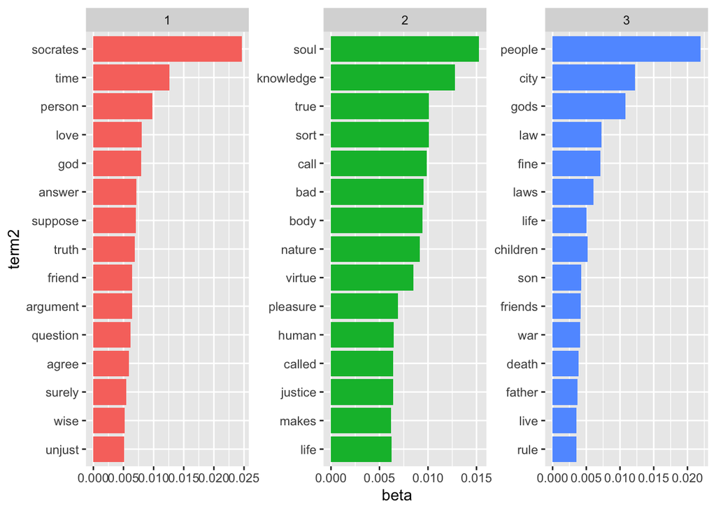

```r
ggplot(
  word_probs_plato,
  aes(term2, beta, fill = as.factor(topic))
) +
  geom_col(show.legend = FALSE) +
  facet_wrap(~ topic, scales = "free") +
  coord_flip()
```

```r
tidy_aristotle <- aristotle %>%
  unnest_tokens(word, sentence_str) %>%
  anti_join(stop_words)
dtm_aristotle = tidy_aristotle %>%
  count(word, id) %>%
  # Cast the word counts into a DTM
  cast_dtm(id, word, n)

lda_out_1 <- LDA(
  dtm_aristotle,
  k = 3,
  method = "Gibbs",
  control = list(seed = 42))

glimpse(lda_out_1)
```

```
## Formal class 'LDA_Gibbs' [package "topicmodels"] with 16 slots
##   ..@ seedwords      : NULL
##   ..@ z              : int [1:393340] 2 3 1 3 3 2 1 2 3 3 ...
##   ..@ alpha          : num 16.7
##   ..@ call           : language LDA(x = dtm_aristotle, k = 3, method = "Gibbs", control = list(seed = 42))
##   ..@ Dim            : int [1:2] 48398 20826
##   ..@ control        :Formal class 'LDA_Gibbscontrol' [package "topicmodels"] with 14 slots
##   ..@ k              : int 3
##   ..@ terms          : chr [1:20826] "ab" "abandon" "abandoned" "abandoning" ...
##   ..@ documents      : chr [1:48398] "45977" "54263" "48263" "54341" ...
##   ..@ beta           : num [1:3, 1:20826] -11.7 -11.7 -14.1 -14.1 -14.1 ...
##   ..@ gamma          : num [1:48398, 1:3] 0.321 0.312 0.292 0.301 0.282 ...
##   ..@ wordassignments:List of 5
##   .. ..$ i   : int [1:354623] 1 1 2 2 2 2 2 2 2 2 ...
##   .. ..$ j   : int [1:354623] 1 7077 1 199 204 7006 9865 9969 10762 11617 ...
##   .. ..$ v   : num [1:354623] 2 3 1 3 3 2 1 2 3 3 ...
##   .. ..$ nrow: int 48398
##   .. ..$ ncol: int 20826
##   .. ..- attr(*, "class")= chr "simple_triplet_matrix"
##   ..@ loglikelihood  : num -2913598
##   ..@ iter           : int 2000
##   ..@ logLiks        : num(0)
##   ..@ n              : int 393340
```

```r
# Tidy the matrix of word probabilities
lda_topics_aristotle <- lda_out_1 %>%
  tidy(matrix = "beta")

# Arrange the topics by word probabilities in descending order
lda_topics_aristotle %>%
  arrange(desc(beta))
```

```
## # A tibble: 62,478 × 3
##    topic term        beta
##    <int> <chr>      <dbl>
##  1     1 animals  0.0186
##  2     2 time     0.0178
##  3     3 nature   0.0154
##  4     1 body     0.0152
##  5     2 motion   0.0144
##  6     1 water    0.0135
##  7     3 reason   0.0125
##  8     2 sense    0.0108
##  9     2 movement 0.00983
## 10     2 true     0.00977
## # … with 62,468 more rows
```

```r
word_probs_aristotle <- lda_topics_aristotle %>%
  group_by(topic) %>%
  top_n(15, beta) %>%
  ungroup() %>%
  mutate(term3 = fct_reorder(term, beta))
```

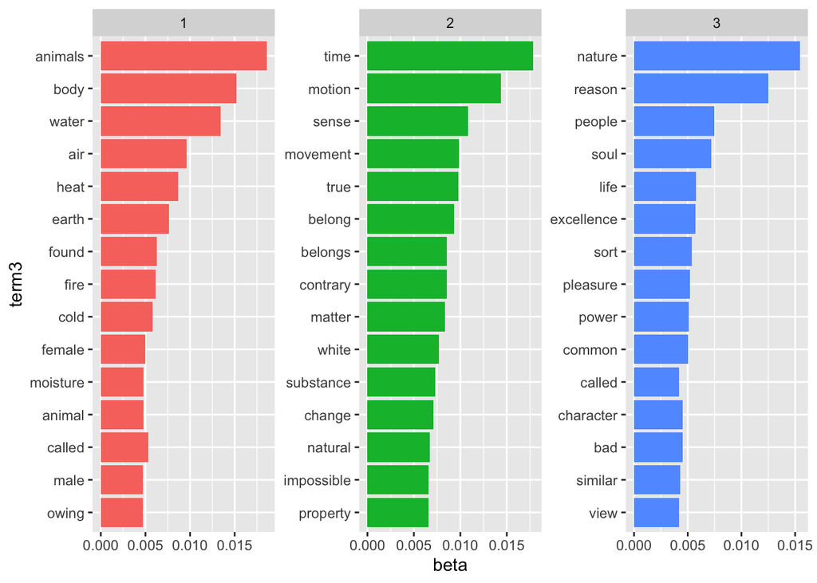

```r
ggplot(
  word_probs_aristotle,
  aes(term3, beta, fill = as.factor(topic))
) +
  geom_col(show.legend = FALSE) +
  facet_wrap(~ topic, scales = "free") +
  coord_flip()
```

In conclusion, we can see that although Plato had direct influence over Aristotle, their views were drastically different from each other. Plato being the more sentimental one, and Aristotle being the more pragmatic and practical one.